# R Notebook

## Before you start

Make sure that you have copied the StudentNoteBook to a folder on you computer, as well as the 2 database files. The 2 database files need to be in the same folder as the StudentNoteBook.

You can test the locataion by running the following code

```r
getwd()
```

Make sure it returns your Exam_HandIn folder. If it does not return, save your StudentNoteBook in the Exam_HandIn folder. If you know that you are saving in the Exam_HandIn folder you can continue.

Now add your name:

Name: Petar Mihaylov

Studentnumber: 3829367

Class: PC06

## Introduction text

In this exam we will go over the theory you worked with earlier. In four sections we will focus on some of the questions and theory presented in the course of DDO. We will start with some questions regarding reading the ERD. Then there are 2 datasets in which we will run several queries, the first you might recognize as the Gapminder, the second is regarding different authors. Lastly we will combine the Queries that you have made with the Tidyverse skills we have obtained earlier in the course.

As we will be using different libraries you need to enable these:

```r
library(tidyverse)
library(ggplot2)
library(DBI)
```

## When finished

After completing all questions you can save the Notebook. Using the *“knit”* function to print your work into an HTML file completes the last task of the test. When you want to upload the work with EFIT make sure to close all applications, otherwise you cannot upload.

When everything is uploaded you can leave the room quietly.

## Understanding a database

For this assignemnt we have the following ERD:

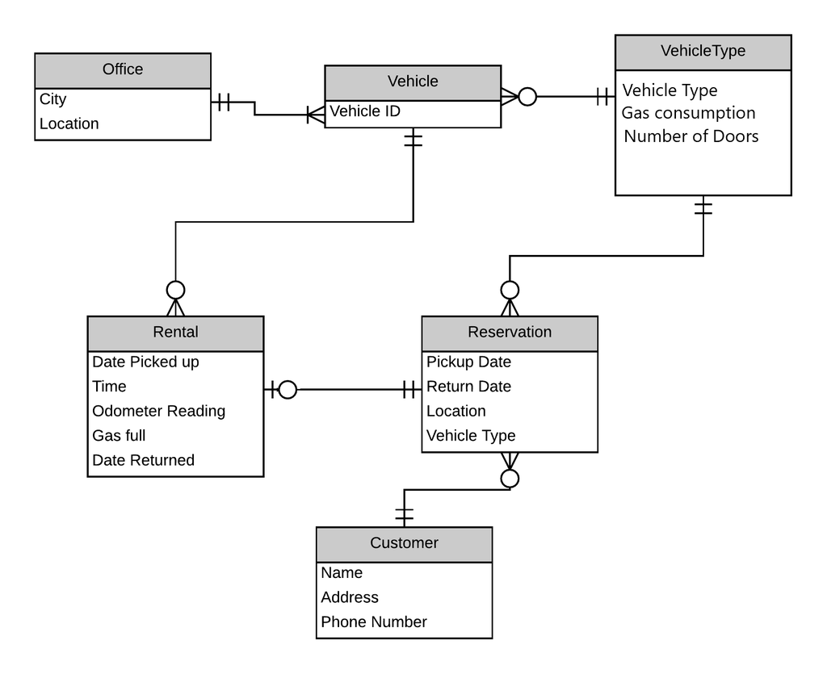

in this ERD there are 6 relationships, for the relations would the following be true or false:

1. A vehicle will always have a rental

> FALSE
2. A Rental will always have 1 Reservation

> TRUE
3. A vehicle is listed with one office only

> TRUE
4. For every vehicle type there is at least 1 vehicle

> FALSE
5. Every table will always need a primary key

> TRUE
6. For a reservation it is optional to have a VehicleType

> FALSE

Describe the following relationships in plain English:

7. The relationship between Office and Vehicle

For the vehicle is mandatory to has at least one office. One office has many vechicles.

8. The relationship between Customer and Reservation

One customer can have zero or many reservations. One reservation can have mandatory one customer.

9. The relationship between Rental and Vehicle

In week 6 we have worked with Gapminder and the tidyverse. Now for the SQL we have the gapminder database available. To see the content of the dataset we can use the following code:

Displaying records 1 - 10

| country | year | lifeExp | pop | gdpPercap |
| --- | --- | --- | --- | --- |
| Afghanistan | 1952 | 28.801 | 8425333 | 779.4453 |
| Afghanistan | 1957 | 30.332 | 9240934 | 820.8530 |
| Afghanistan | 1962 | 31.997 | 10267083 | 853.1007 |
| Afghanistan | 1967 | 34.020 | 11537966 | 836.1971 |
| Afghanistan | 1972 | 36.088 | 13079460 | 739.9811 |
| Afghanistan | 1977 | 38.438 | 14880372 | 786.1134 |
| Afghanistan | 1982 | 39.854 | 12881816 | 978.0114 |
| Afghanistan | 1987 | 40.822 | 13867957 | 852.3959 |
| Afghanistan | 1992 | 41.674 | 16317921 | 649.3414 |
| Afghanistan | 1997 | 41.763 | 22227415 | 635.3414 |

10. Show the name of countries, year, and life expectation from the table gapminder.

Displaying records 1 - 10

| name | year | lifeExp |
| --- | --- | --- |
| Afghanistan | 1952 | 28.801 |
| Afghanistan | 1957 | 30.332 |
| Afghanistan | 1962 | 31.997 |
| Afghanistan | 1967 | 34.020 |
| Afghanistan | 1972 | 36.088 |
| Afghanistan | 1977 | 38.438 |
| Afghanistan | 1982 | 39.854 |
| Afghanistan | 1987 | 40.822 |
| Afghanistan | 1992 | 41.674 |
| Afghanistan | 1997 | 41.763 |

11. List all the countries from the gapminder table. Make sure there are no duplicate lines.

Displaying records 1 - 10

| country |
| --- |
| Afghanistan |
| Albania |
| Algeria |
| Angola |
| Argentina |
| Australia |
| Austria |
| Bahrain |
| Bangladesh |
| Belgium |

12. List the information of China in 1967 from the Gapminder table

1 records

| country | year | lifeExp | pop | gdpPercap |
| --- | --- | --- | --- | --- |
| China | 1967 | 58.38112 | 754550000 | 612.7057 |

13. What is the total population in 2007 according to the gapminder table

1 records

| sum(pop) |
| --- |
| 6251013179 |

14. Calculate the average gdpPercap of each country

Displaying records 1 - 10

| country | average_gdp |
| --- | --- |
| Afghanistan | 802.6746 |
| Albania | 3255.3666 |
| Algeria | 4426.0260 |
| Angola | 3607.1005 |
| Argentina | 8955.5538 |
| Australia | 19980.5956 |
| Austria | 20411.9163 |
| Bahrain | 18077.6639 |
| Bangladesh | 817.5588 |
| Belgium | 19900.7581 |

15. Show the total population, average population, the minimum, and maximum population for Canada

1 records

| total | Average | minimum | maximum |
| --- | --- | --- | --- |
| 293555608 | 24462967 | 14785584 | 33390141 |

16. From the database we also have the table countries, give the country and continent code:

Displaying records 1 - 10

| country | continent |
| --- | --- |
| Afghanistan | Asia |
| Albania | Europe |
| Algeria | Africa |
| Angola | Africa |
| Argentina | Americas |
| Australia | Oceania |
| Austria | Europe |
| Bahrain | Asia |
| Bangladesh | Asia |
| Belgium | Europe |

17. how many countries are there per continent?

5 records

| continent | count () |
| --- | --- |
| Oceania | 2 |
| Europe | 30 |
| Asia | 33 |
| Americas | 25 |
| Africa | 52 |

18. What is the population per continent?

5 records

| continent | sum(g.pop) |
| --- | --- |
| Oceania | 212992136 |
| Europe | 6181115304 |
| Asia | 30507333901 |
| Americas | 7351438499 |
| Africa | 6187585961 |

## Books queries

For a second set of queries we have a database with the following database model:

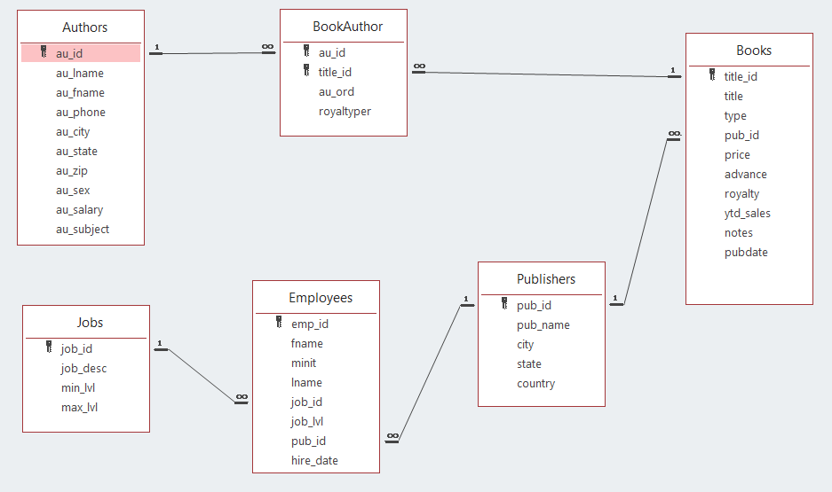

19. Show a list of all authors whose first name starts with the ‘An’ characters.

8 records

| au_id | au_lname | au_fname | au_phone | au_city | au_state | au_zip | au_sex | au_salary | au_subject |
| --- | --- | --- | --- | --- | --- | --- | --- | --- | --- |
| 427-17-2319 | Dull | Ann | 415 836-7128 | Palo Alto | CA | 94301 | F | 14000 | Travel |
| 427-17-6319 | Dull4 | Ann3 | 415 536-7128 | Rockville | MD | 94301 | F | 15000 | Sci-fi |
| 427-67-2319 | Dull3 | Ann2 | 415 636-7128 | Palo Alto | CA | 94301 | F | 16000 | Travel |
| 627-17-2319 | Dull1 | Ann1 | 415 736-7128 | Palo Alto | CA | 94301 | F | 30000 | Sci-fi |
| 899-46-2035 | Ringer | Anne1 | 801 726-0752 | Salt Lake City | UT | 84152 | M | 3000 | Sci-fi |
| 899-46-3035 | Ringer1 | Anne3 | 801 526-0752 | Lawrence | KS | 84152 | M | 4000 | Sci-fi |
| 899-46-8035 | Ringer4 | Anne3 | 801 56-0752 | Salt Lake City | UT | 84152 | M | 4000 | Sci-fi |
| 899-76-2035 | Ringer3 | Anne1 | 801 726-0752 | Salt Lake City | UT | 84152 | M | 4000 | Travel |

20. Show a list of all authors where the last 4 numbers of the id start with a 3 follow with three numbers.

Displaying records 1 - 10

| au_id | au_lname | au_fname | au_phone | au_city | au_state | au_zip | au_sex | au_salary | au_subject |
| --- | --- | --- | --- | --- | --- | --- | --- | --- | --- |
| 172-32-3176 | White4 | Johnson3 | 408 796-7223 | Menlo Park | CA | 94025 | F | 8000 | Sci-fi |
| 238-95-3766 | Carson4 | Cheryl3 | 415 848-7723 | Berkeley | CA | 94705 | M | 13000 | Action |
| 372-71-3249 | Yokomoto1 | Akiko1 | 415 835-4228 | Walnut Creek | CA | 94595 | M | 9000 | Romance |
| 527-72-3246 | Greene | Morningstar | 615 297-2723 | Nashville | TN | 37215 | M | 25000 | Romance |
| 527-82-3246 | Greene3 | Morningstar2 | 615 497-2723 | Nashville | TN | 37215 | U | 27000 | Romance |
| 672-31-3249 | Yokomoto3 | Akiko2 | 415 735-4228 | Walnut Creek | CA | 94595 | M | 4000 | Sci-fi |
| 672-71-3249 | Yokomoto | Akiko | 415 935-4228 | San Jose | CA | 94595 | M | 6000 | Sci-fi |
| 724-80-3391 | MacFeather4 | Stearns3 | 415 654-7128 | Oakland | CA | 94612 | F | 17000 | Travel |
| 798-72-3567 | Ringer1 | Albert2 | 801 626-0752 | Salt Lake City | UT | 84152 | F | 22000 | Sci-fi |
| 827-72-3246 | Greene1 | Morningstar1 | 615 397-2723 | Nashville | TN | 37215 | M | 26000 | Romance |

Displaying records 1 - 10

| au_zip | maximum_salary | au_id |
| --- | --- | --- |
| 20853 | 29000 | 607-91-6654 |
| 37215 | 27000 | 527-82-3246 |
| 46403 | 13000 | 422-51-5454 |
| 48105 | 24000 | 512-45-1867 |
| 66044 | 8000 | 341-92-1782 |
| 84152 | 22000 | 798-72-3567 |
| 94025 | 19000 | 272-32-1176 |
| 94130 | 22000 | 486-39-1786 |
| 94301 | 30000 | 627-17-2319 |
| 94595 | 9000 | 372-71-3249 |

22. What is the total price for books sold from the ‘Algodata Infosystems’ publisher?

1 records

| total_Price |
| --- |
| 94.88 |

23. List all employees who are involved in publishing a book for the Binnet & Hardley publisher. (use a subquery).

Displaying records 1 - 10

| fname | lname | emp_id |
| --- | --- | --- |
| Anabela | Domingues | ARD36773F |
| Daniel | Tonini | DBT39435M |
| Elizabeth | Lincoln | ENL44273F |
| Helen | Bennett | H-B39728F |
| Lesley | Brown | L-B31947F |
| Martine | Rance | M-R38834F |
| Peter | Franken | PHF38899M |
| Paolo | Accorti | PMA42628M |
| Paul | Henriot | PXH22250M |
| Victoria | Ashworth | VPA30890F |

24. What is the total number of business books that are written per gender of the author? List gender and the total number of books.

2 records

| au_sex | count(b.title_id) |
| --- | --- |
| F | 4 |
| M | 2 |

25. Who wrote the book with title ‘Is Anger the Enemy?’? List the first and the last names of the author and the author id.

2 records

| au_fname | au_lname | au_id |
| --- | --- | --- |
| Anne1 | Ringer | 899-46-2035 |
| Albert | Ringer | 998-72-3567 |